# Glassdoor Exploratory Data Analysis

Saliem Tadesse

7/29/2020

### *Comparison* *of* *Data* *Science* *Positions* *Before* *and* *During* *Covid-19*

#### **Contents:**

1. Data Scrapping
2. Data Cleaning
3. Exploratory Data Analysis
4. Missing Values
5. Average salary
6. Company Rating
7. Average Salary by Job Type 2020
8. Counts by Job Type
9. Salary by Seniority Level
10. Job Count by State
11. Salary by Job Type by State
12. Data Analyst
13. Data Scientist
14. Data Engineer
15. Data Modeler
16. Cleaning 2019 Data
17. Average Salary by Job Type 2019
18. Job Count Comparison 2019-2020
19. Percentage of Job Types
20. Comparison of the Top Highest Paying States in 2020 to 2019

#### **Project Overview**

This project puts an insight in to the available data science positions, compares job counts and salary across states and finally compares data science positions to the year 2019.The data science positions data is scrapped from glassdoor website, cleaned and organized to conduct exploratory data analysis. Each sections listed in the contents above are described in detailed steps below.

#### **1. Data scrapping**

This section portrays a step by step data scrapping approach. The methods of scrapping data using r is referenced from Chris Keeney (https://www.rpubs.com/chrisjkeeney/Glassdoor). Hence, using this method the variables scrapped include;job title,company name,city and state,Company rating, salary and job posted date.

#### **2. Data cleaning**

Values that contain un nesessary characters or other information is removed. Inaddition, abbreviated words are converted in to a same format to keep consistency. For some observations the value of state was manually inserted by reffering to the stated city.On the other hand, 212 observation did not include state variable and salary hence were removed from the data.

#### **3. Missing values**

A total of 15,908 data science/relaated positions were scrapped and the counts of missing values are descibed in the table below.

| Variables | Missing_Value_Counts |
| --- | --- |
| Job_Title | 0 |
| Company_Name | 0 |
| City | 0 |
| State | 0 |
| Company_Rating | 1950 |
| Minimum_Salary | 5172 |
| Maximum_Salary | 5172 |
| Post_Date | 3144 |
| Salary_Hourly | 0 |
| Average_Salary | 5172 |

#### **4. Average salary using histogram**

The graph indicates a fair normal distribution with an average salary ranging between 50k-140k for the different data science positions. A good chunk of positions indicate a salary range of 150k-180k and few indicate more than 200k. The boxplot also indicates that the salary data is normaly distributed with some outliers.

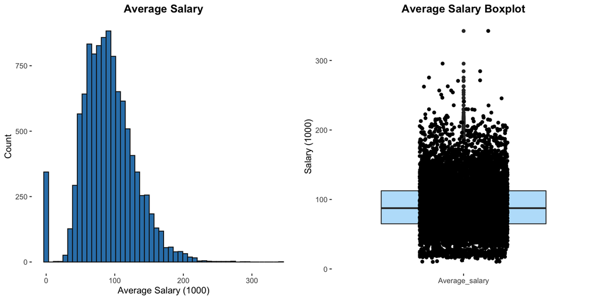

#### **5. Company rating using histogram**

Majority of the companies have good ratings; their ratings range between 3 and 4.5.Unfortunetly fewer companies tend to have ratings less than 2. On the conterary there seems to be a larger number of companies that has a rating ranked 5.

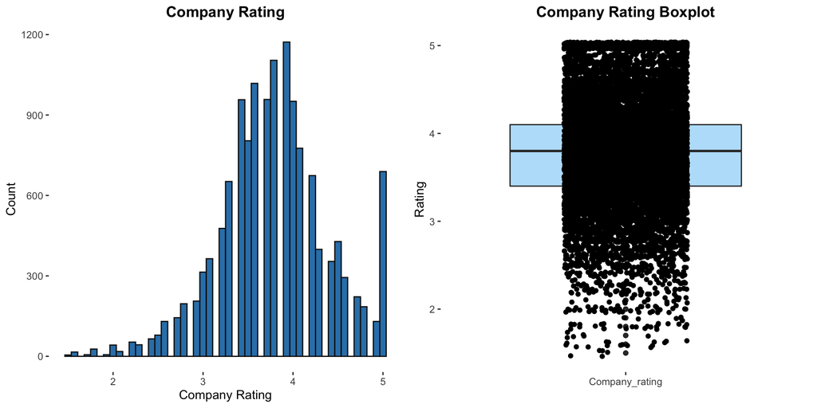

#### **6. Average salary by job type 2020 boxplot**

For data scientist, data analyst and data engineers the data is fairly normaly distributed but not as in the case of data modeler. More outliers are seen in the data analyst and data scientist positions. This could be due to a salary increase by seniority and experience levels.

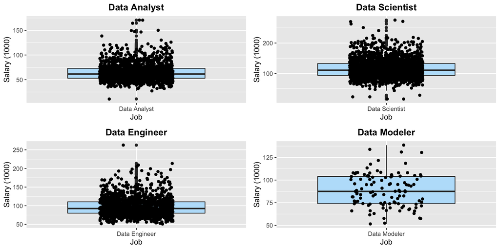

#### **7. Counts by job type**

This shows that there is a higher demand for data scientist,data analyst and data engineer respectively. Data modeler and data entry positions on the other hand has lower demand.

| Data Scientist | Data Analyst | Data Engineer | Data Modeler | Data Entry |
| --- | --- | --- | --- | --- |
| 3206 | 2802 | 2582 | 179 | 5 |

#### **8. Salary by seniority level**

|  | Data_Analyst | Data_Scientist | Data_Engineer | Data_Modeler |
| --- | --- | --- | --- | --- |
| Senior | 80.25 | 133 | 111.5 | 101 |
| Junior | 46.5 | 80.5 | 79.75 | NA |
| Director | 77.5 | 170 | 184.5 | NA |
| Associate | 54 | 99.5 | 69.5 | NA |
| Assistant | 34 | NA | NA | NA |

#### **9. Job count by state**

Out of the 43 states taken in this analysis North Carolina has the hieghst demand in data science positions. Similarly, as described in the graph below New York,New Jersey,Maryland,Virginia,Illinois,California,Massachusetts,Pennsylvania and Texas show almost a similar number of available data science positions.On the other hand, in states like Maine,Mississippi,Hawaii has the lowest number of data science positions.

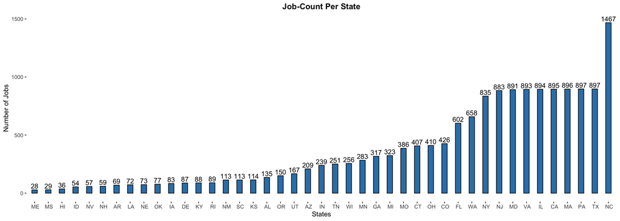

#### **10. Salary by job type by state**

##### **11. *Data* *Analyst***

The highest paying state for data analyst position is Georgia and Nevada is the lowest paying state. Data analyst salaries across majority of the states does not show a bigger gap. Some expected expensive states to live in such as New York and California has a relative higher pay when compared to other states.

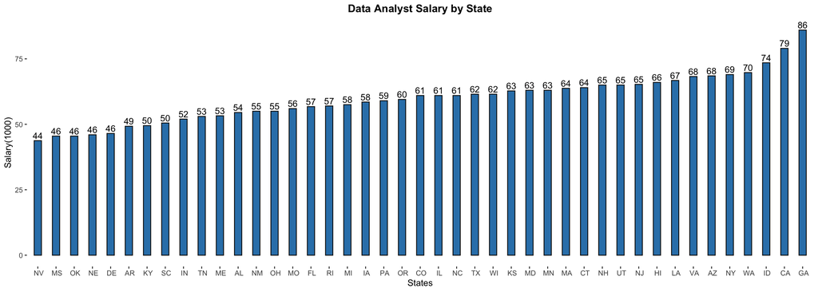

##### **12. *Data* *Scientist***

Relative to data analyst position, data scientist position is a higher paying job. Salary ranges between the lowest 72k in South Carolina to the highest 138k in california.Majority of the states pay around 90k.

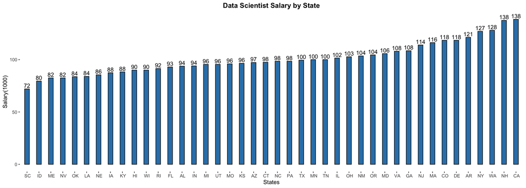

##### **13. *Data* *Engineer***

California is the highest paying state for data engineering positions while,Idaho and Mississippi are the lowest paing states.

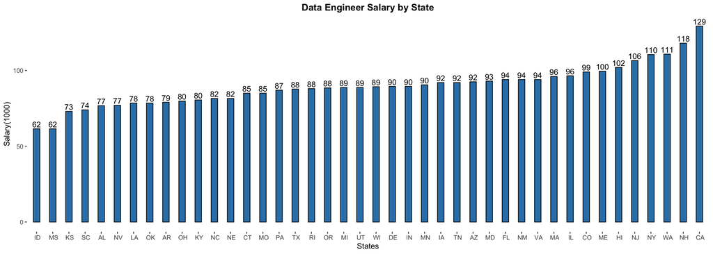

##### **14. *Data* *Modeler***

Delware is the highest paying state for data modeler position while Washington state is the lowest paying state.

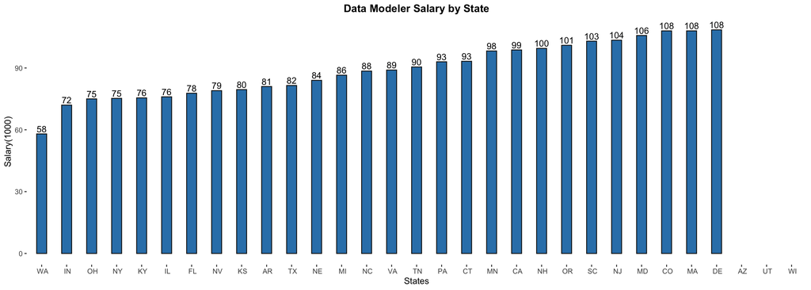

#### **15. Cleaning 2019 data**

unnessesary words,characters and symbols were removed to maintain consistency.

#### **16. Average salary by job type 2019**

As indicated in the graph except for data modeler position, the other positions havea normal distribution. The data is highly disperssed as in the case of data modeler. There exists a higher salary pay for the stated positions.

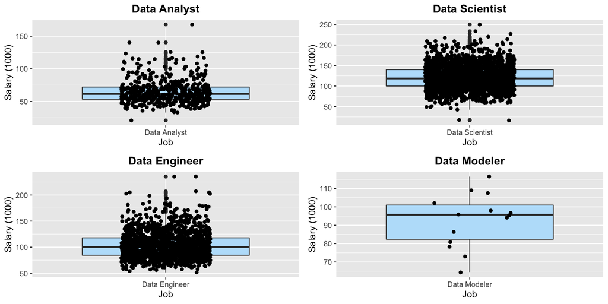

#### **17. Job count comparison 2019-2020**

In 2019 data scientist and data engineering positions where higher when compared to the year 2020.While data analyst and data modeler positions are higher in 2020.

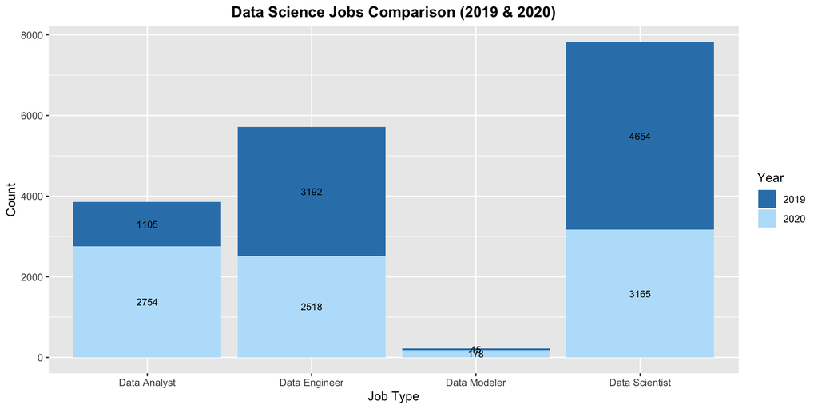

#### **18. Percentage of job types**

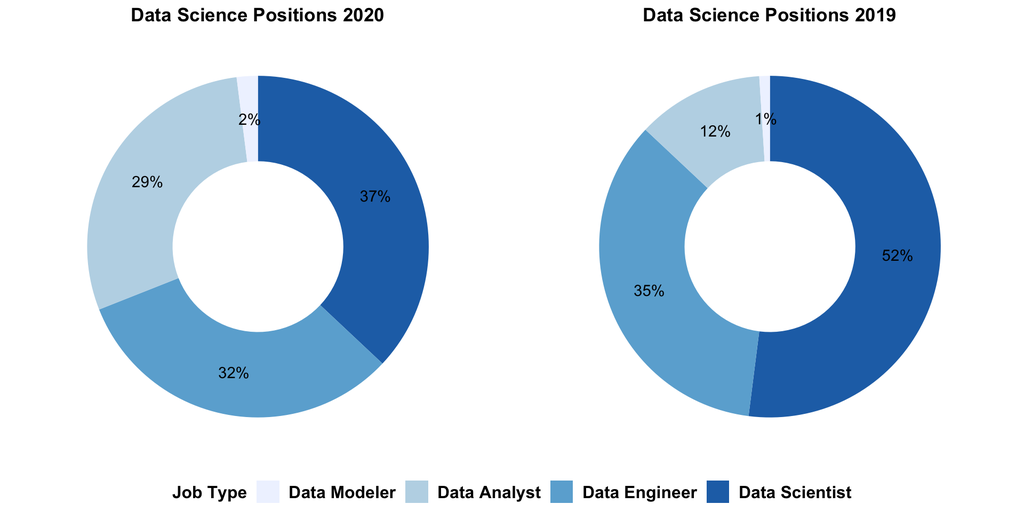

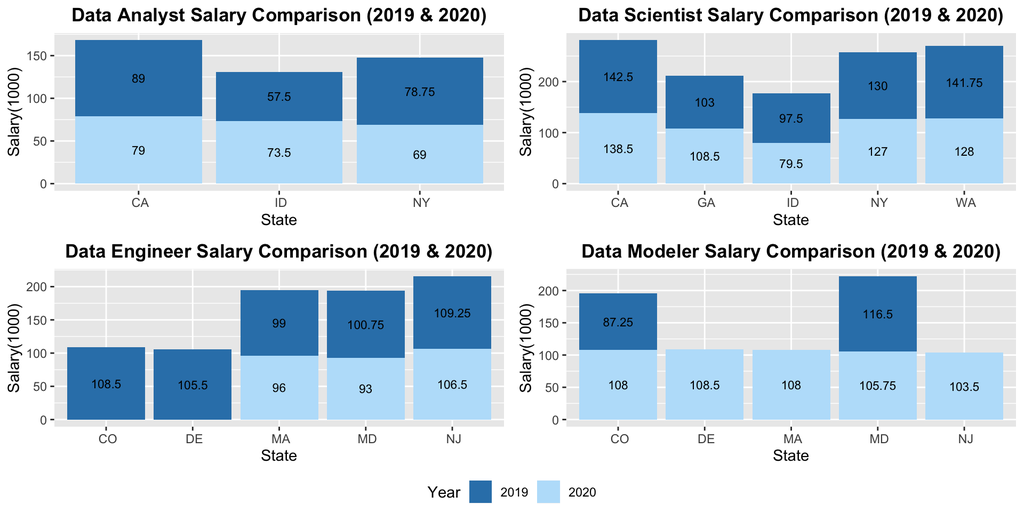